# Fraud Detection Model

Joy Kearney

23 November 2018

# Exploratory Data Analysis and Model Fitting on Credit Scoring Data

## Table of Contents

1. Introduction
2. Exploratory Data Analysis
3. Data Cleaning & Feature Engineering
4. Modelling  
   5.0 Misclassification Cost 6.0 Scoring Dataset & Model Testing 9.0 Conclusion Refernces

Packages installed and used in the project listed below:

```r
library(adabag)
library(gbm)
```

```r
library(tree)
library(ISLR)
library(rpart)
library(rpart.plot)
library(randomForest)
library(DataExplorer)
library(dplyr)
library(plotly)
library(ggplot2)
```

## 1.1 The data:

The dataset has 14 columns showing the financial and demographic information for use in credit scoring examples. The dataset was read into Rstudio and the column names changed for ease in Exploratory Data Analysis.

```r
# read in the training data

traindata<- read.csv("Fraud_Data_train.csv", na.strings =c(""))
colnames(traindata) <- c('ID', 'Current_Acct', 'Credit_History', 'Loan_Reason', 'Savings_Acct', 'Employment', 'Personal_Status', 'Housing', 'Job_Type', 'Foreign_National', 'Length_Current_Acct(Months)', 'Residence_Time(Years)', 'Age', 'Credit_Standing')

# lets have a proper look at the data

names(traindata)
```

```
##  [1] "ID"                          "Current_Acct"
##  [3] "Credit_History"              "Loan_Reason"
##  [5] "Savings_Acct"                "Employment"
##  [7] "Personal_Status"             "Housing"
##  [9] "Job_Type"                    "Foreign_National"
## [11] "Length_Current_Acct(Months)" "Residence_Time(Years)"
## [13] "Age"                         "Credit_Standing"
```

```r
head(traindata)
```

```
##   ID Current_Acct Credit_History     Loan_Reason Savings_Acct Employment
## 1  1      No Acct       All Paid         Car New          Low     Medium
## 2  2     0Balance        Current         Car New          Low      Short
## 3  3     0Balance        Current         Car New      No Acct       Long
## 4  4     0Balance        Current       Furniture      No Acct       Long
## 5  5      No Acct       All Paid Small Appliance      No Acct       Long
## 6  6          Low        Current         Car New       MedLow Very Short
##   Personal_Status Housing   Job_Type Foreign_National
## 1          Single     Own Management               No
## 2        Divorced     Own    Skilled               No
## 3        Divorced     Own    Skilled               No
## 4            <NA>     Own    Skilled               No
## 5          Single   Other    Skilled              Yes
## 6        Divorced     Own  Unskilled               No
##   Length_Current_Acct(Months) Residence_Time(Years) Age Credit_Standing
## 1                           7                     3  44            Good
## 2                          16                     2  28             Bad
## 3                          25                     2  28             Bad
## 4                          31                     4  30            Good
## 5                           7                     4  35            Good
## 6                          13                     2  22            Good
```

```r
dim(traindata)
```

```
## [1] 780  14
```

```r
View(traindata)
```

The 14th column (Credit_Standing) is the indicator variable on loan defaults, which can be used as the target in supervised learning. The following are the descriptive tags given to these variables:

1.ID 2.Current_Acct 3.Credit_History 4.Loan_Reason 5.Savings_Acct 6.Employment 7.Personal_Status 8.Housing 9.Job_Type 10.Foreign_National 11.Length_Current_Acct(Months) 12.Residence_Time(Years) 13.Age 14.Credit_Standing

A summary of the data can be seen below:

```r
summary(traindata)
```

```
##        ID          Current_Acct   Credit_History          Loan_Reason
##  Min.   :  1.0   0Balance:263   All Paid :138    Car New        :191
##  1st Qu.:195.8   High    : 45   Bank Paid: 63    Small Appliance:186
##  Median :390.5   Low     :201   Critical : 92    Furniture      :160
##  Mean   :390.5   No Acct :271   Current  :423    Business       : 82
##  3rd Qu.:585.2                  Delay    : 64    Car Used       : 75
##  Max.   :780.0                                   Education      : 45
##                                                  (Other)        : 41
##   Savings_Acct      Employment  Personal_Status  Housing
##  High   : 29   Long      :186   Divorced:273    Other: 94
##  Low    :500   Medium    :140   Married : 70    Own  :524
##  MedHigh: 49   Retired   :  2   Single  :431    Rent :157
##  MedLow : 80   Short     :242   NA's    :  6    NA's :  5
##  No Acct:122   Unemployed: 43
##                Very Short:134
##                NA's      : 33
##        Job_Type   Foreign_National Length_Current_Acct(Months)
##  Management:101   No :253          Min.   :  5.0
##  Skilled   :498   Yes:527          1st Qu.: 13.0
##  Unemployed: 19                    Median : 19.0
##  Unskilled :162                    Mean   : 23.2
##                                    3rd Qu.: 29.5
##                                    Max.   :120.0
##
##  Residence_Time(Years)      Age        Credit_Standing
##  Min.   :-2.000        Min.   :18.00   Bad :319
##  1st Qu.: 2.000        1st Qu.:26.00   Good:461
##  Median : 3.000        Median :32.00
##  Mean   : 2.868        Mean   :34.75
##  3rd Qu.: 4.000        3rd Qu.:41.00
##  Max.   :10.000        Max.   :99.00
##
```

## 1.2 Cleaning Data

As mentioned above the column names were changed for descriptive purposes and for ease of use during Exploratory Data Analysis. One of the main issues with the data apart from the column names was missing values and outliers. The data has a total of 44 missing values (NAs). With the help of the package DataExplorer the graph below was generated to describe the missing values:

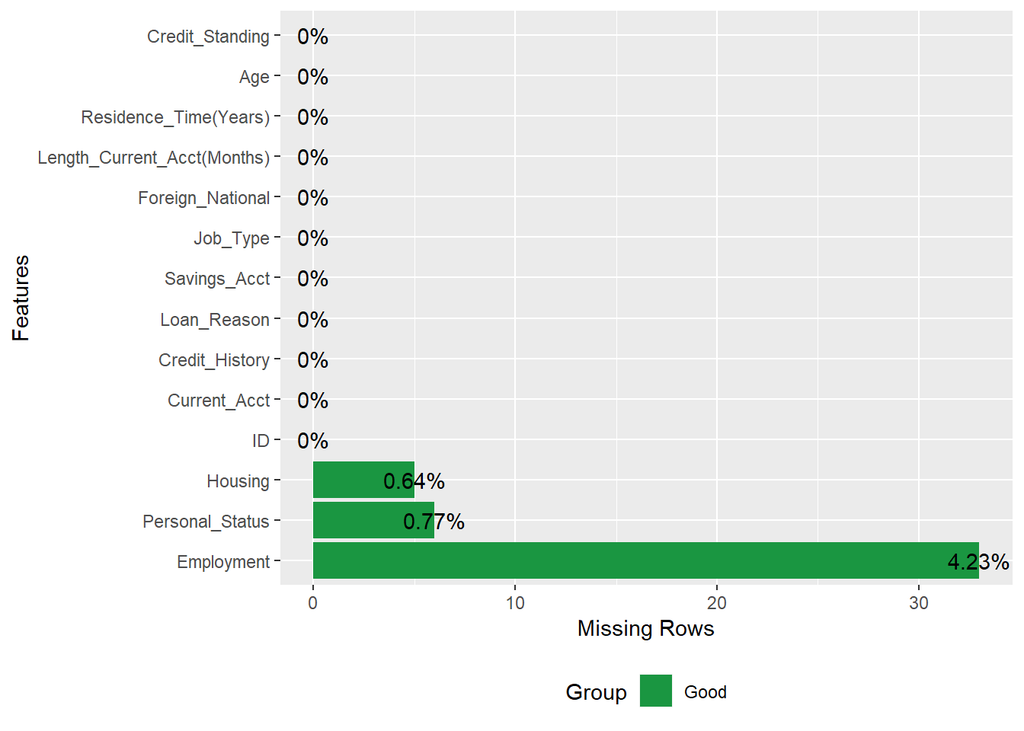

```r
library(DataExplorer)
plot_missing(traindata)
```

```r
summary(traindata$`Residence_Time(Years)`)
```

```
##    Min. 1st Qu.  Median    Mean 3rd Qu.    Max.
##  -2.000   2.000   3.000   2.868   4.000  10.000
```

```r
traindata <- traindata[-391, ]  # cannot have minus years in residence. May be data entry problem so this observation will be deleted
summary(traindata$`Residence_Time(Years)`) # Summary now looks better
```

```
##    Min. 1st Qu.  Median    Mean 3rd Qu.    Max.
##   1.000   2.000   3.000   2.874   4.000  10.000
```

## Exploratory Data Analysis

A 4-step process was adopted for Exploratory Data Analysis. This process will reflect the vigorous EDA carried out along with plots and conclusion. The 4-step process has the following headings:

2.1 Univariate analysis and plots 2.2 Bivariate analysis and plots 2.3 Multivariate analysis and plots 2.4 Final plots and Conclusion

Firstly, to get a feel for the data a summary report was generated using the package DataExplorer.

```r
#create_report(traindata)
```

#### 2.1 Univariate Analysis

This package was used to get a general feel for the data and to determine a path of investigation. From this report we can see that there are 4 continuous variables including the columns ID, Age, Residence time and current account length. The other 10 variables are categorical. The data had 780 rows, 44 NAs which means there is 737 complete rows. The report also contains some univariate plots. The first plot that stood out was the univariate Credit_Standing variable as it shows that of the 780 previous customers 319 of them were considered bad loan applicants and 461 were good loan applicants.

```r
table(traindata$Credit_Standing)
```

```
##
##  Bad Good
##  319  460
```

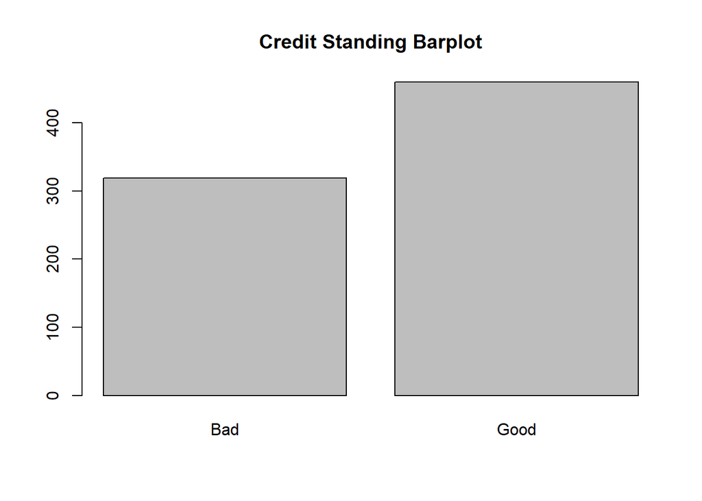

```r
barplot(table(traindata$Credit_Standing), main = "Credit Standing Barplot")
```

Approximately 41% of the Scoring set have been reported as bad loans. This is sufficiently high. Another univariate plot investigated was Employment plot. The plot can be generated below:

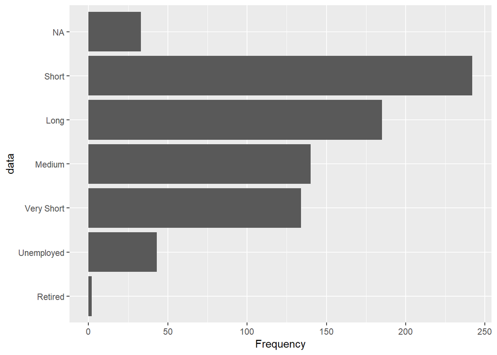

```r
plot_bar(traindata$Employment)
```

```r
table(traindata$Employment)
```

```
##
##       Long     Medium    Retired      Short Unemployed Very Short
##        185        140          2        242         43        134
```

As mentioned this variable has a total of 33 missing values. As can be depicted by the plot approximately 54% of the customers are in short employment, very short employment or unemployed. Proving steady income is an important parametric of credit scoring so Employment will be looked at further.

A subset divining the data by Credit Standing lead to investigating the characteristics of good loan applicants and the characteristics that bad loan applicants.

```r
good <- subset(traindata, Credit_Standing=="Good")

bad <- subset(traindata, Credit_Standing=="Bad")
```

By looking at all the variables with respect to good loan applicants and bad loan applicants It helped to narrow investigation and to really understand the parameters that define a good loan applicant and a bad loan applicant. As mentioned employment was an area of investigation that needed more attention.

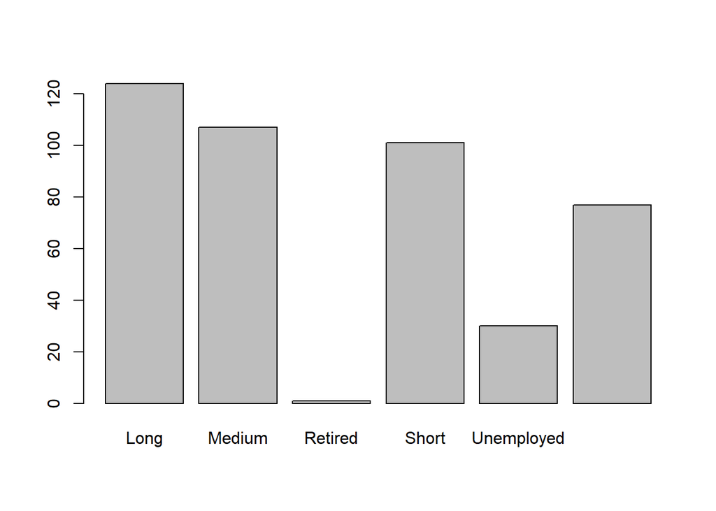

```r
barplot(table(good$Employment))# now we are talking big difference between the two. good has
```

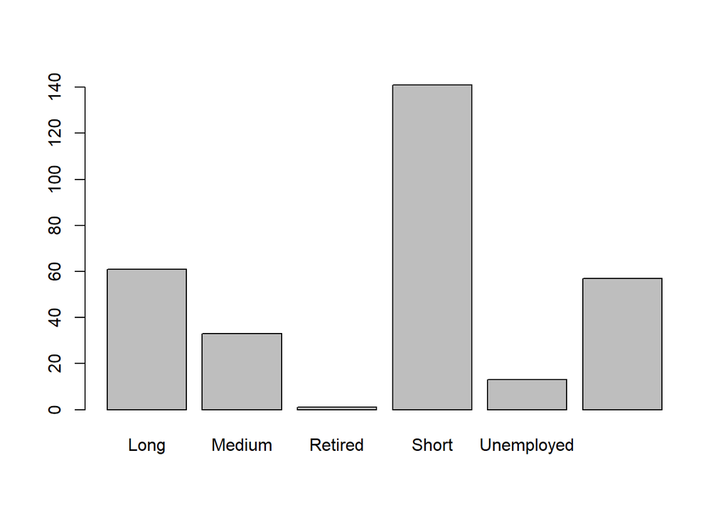

```r
barplot(table(bad$Employment))
```

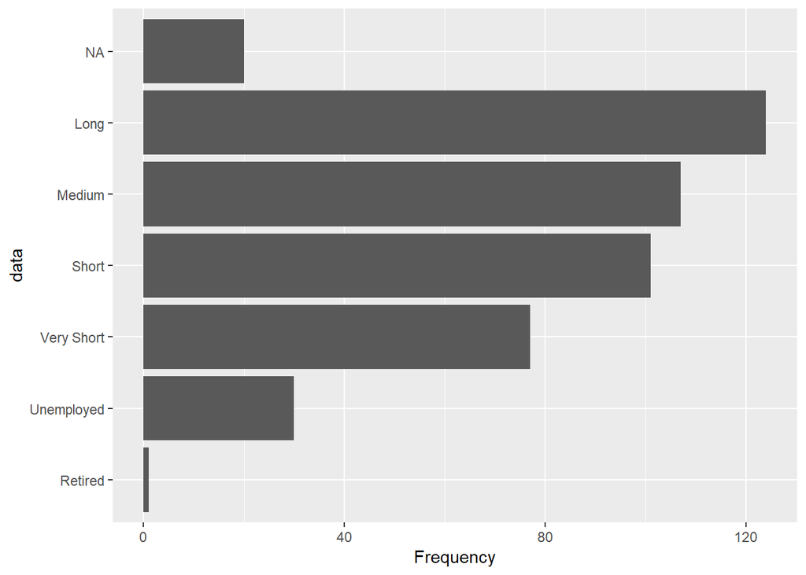

```r
plot_bar(good$Employment) # had to use dataexplorer as nas were not being graphed
```

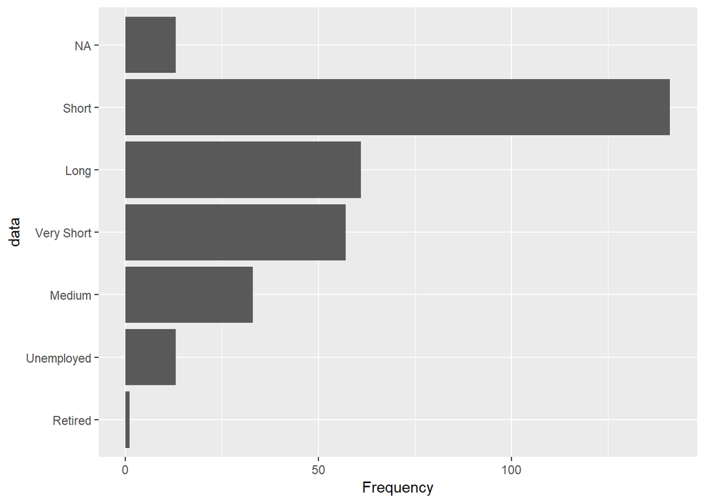

```r
plot_bar(bad$Employment)
```

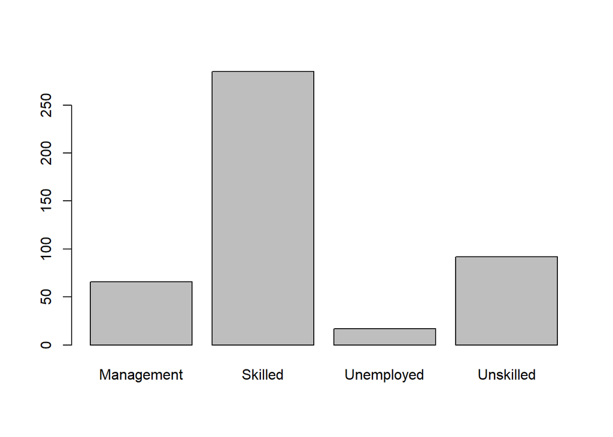

```r
barplot(table(good$Job_Type))# this is weird less unemployed in the bad group than the good
```

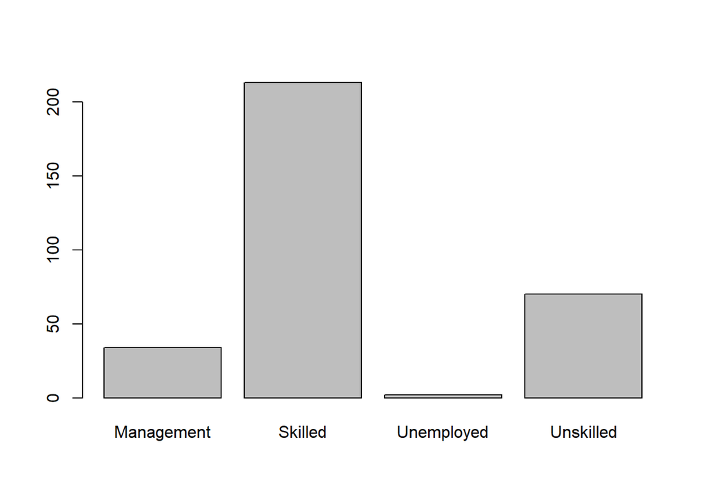

```r
barplot(table(bad$Job_Type))
```

```r
table(good$Job_Type)# very weird check out further
```

```
##
## Management    Skilled Unemployed  Unskilled
##         66        285         17         92
```

```r
table((bad$Job_Type))
```

```
##
## Management    Skilled Unemployed  Unskilled
##         34        213          2         70
```

It is obvious from the graphs produced here that the good loan applicants generally have long term and medium employment when comapred with bad loan applicants which have marginally more short-term employment. However, it was noted that there were 17 more unemployed customers in the good loan data. This will be investigated more in the bivariate section. Moving on from employment the Job Type was explored. Again, it seems good loan applicants reported having more skilled and management jobs when compared with bad applicants.

The difference in credit history was also explored between the good and bad applicants and the following findings observed: Bad loan applications reported having more Critical (28%) Credit History compared to good loan customers.  
Good loan customers had marginally more “All Paid” and “Bank Paid” Credit History status compared to bad loan applicants.

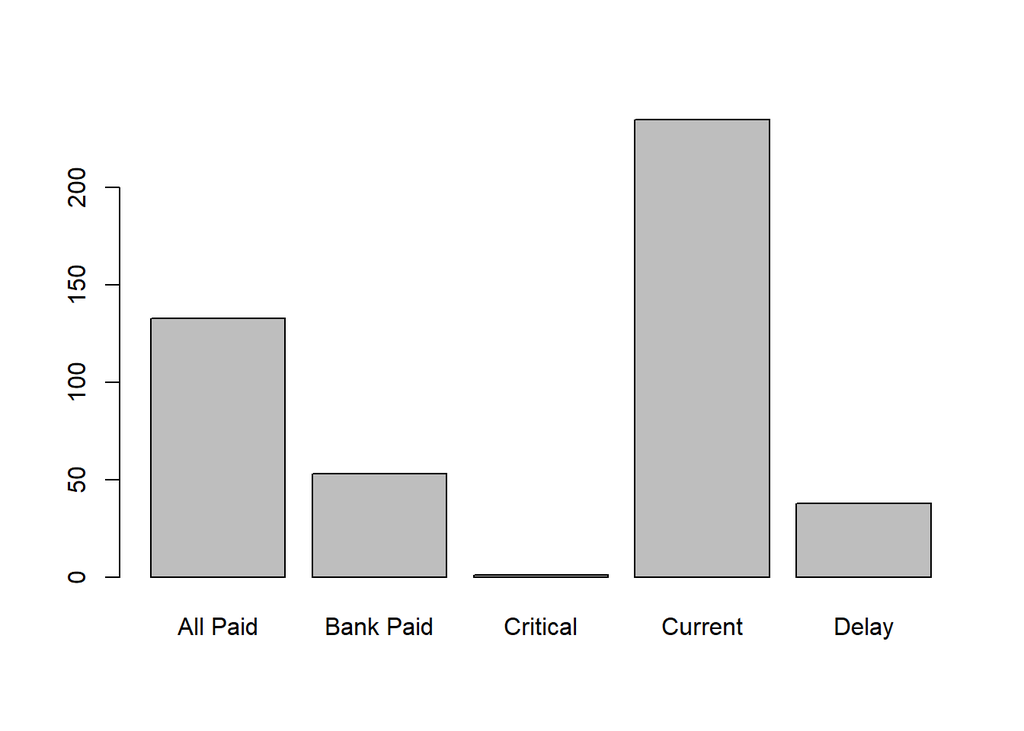

```r
barplot(table(good$Credit_History))# good at telling us the difference. bad has alot more critical accounts whre as good have few. good has high all paid
```

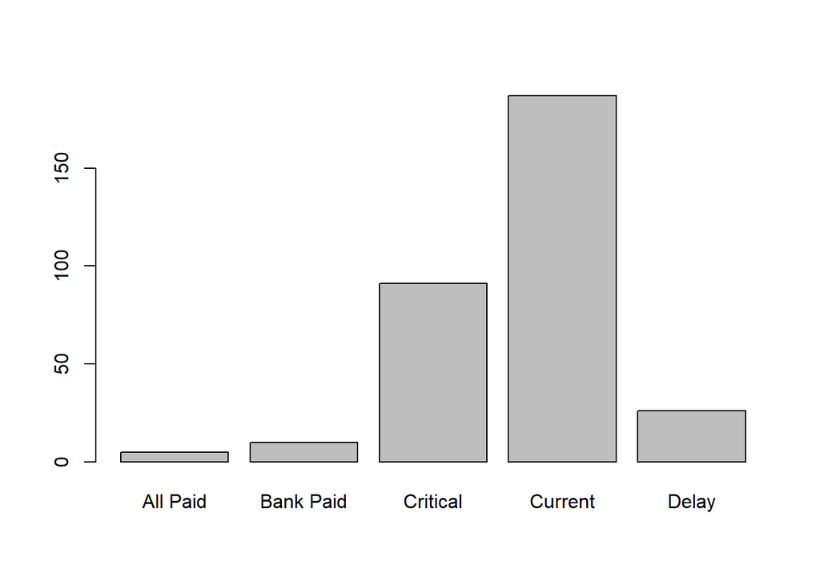

```r
barplot(table(bad$Credit_History))
```

```r
table(good$Credit_History)# not so good for telling us the diff between good and bad
```

```
##
##  All Paid Bank Paid  Critical   Current     Delay
##       133        53         1       235        38
```

```r
table(bad$Credit_History)
```

```
##
##  All Paid Bank Paid  Critical   Current     Delay
##         5        10        91       187        26
```

More interesting observations from the subsets good and bad were as follows:  
10% more good loan applicants own their own home compared with bad loan applicants  
The data set reports a high number of foreign nationals.

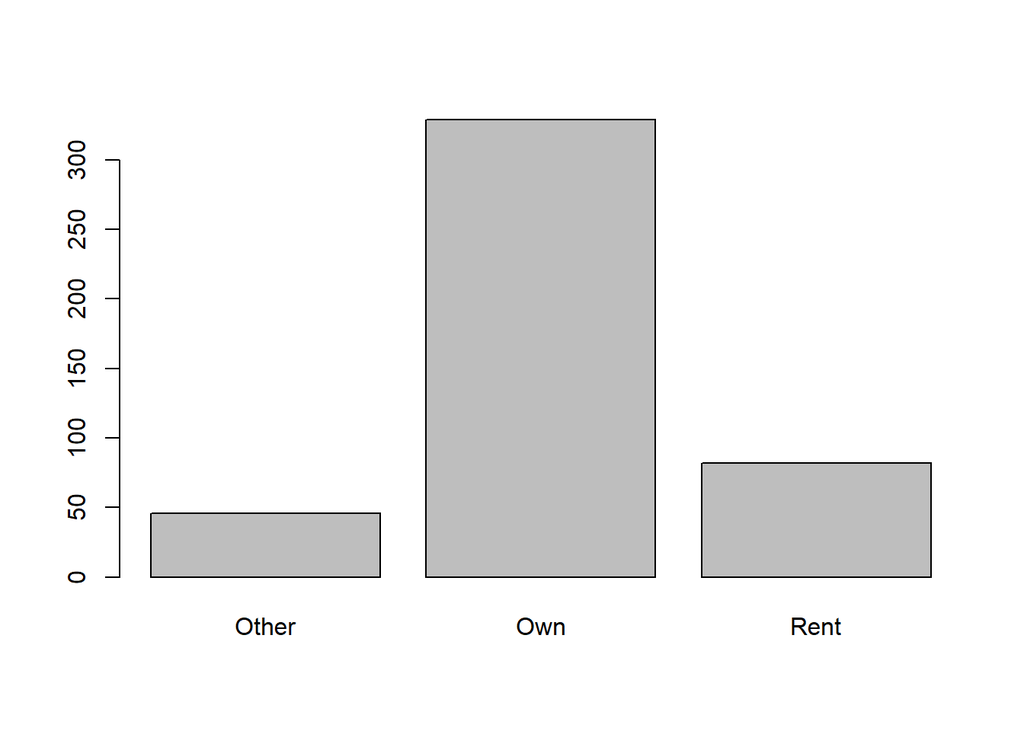

```r
barplot(table(good$Housing))
```

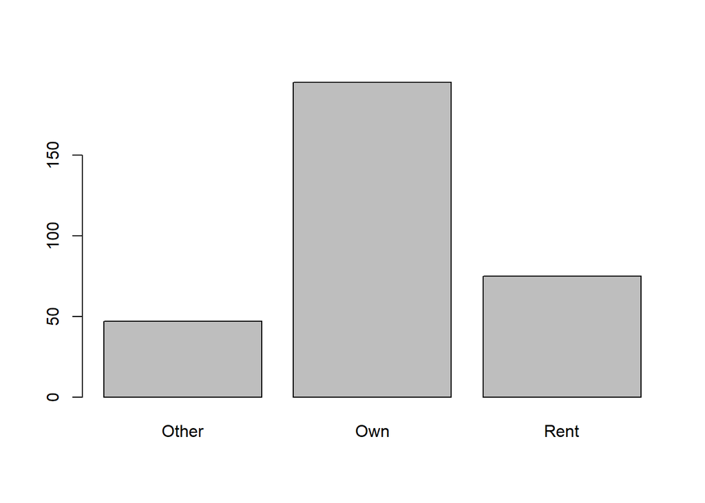

```r
barplot(table(bad$Housing))
```

```r
table(good$Housing) # good for comparisin. almost double in the good group own their own house
```

```
##
## Other   Own  Rent
##    46   329    82
```

```r
table((bad$Housing))
```

```
##
## Other   Own  Rent
##    47   195    75
```

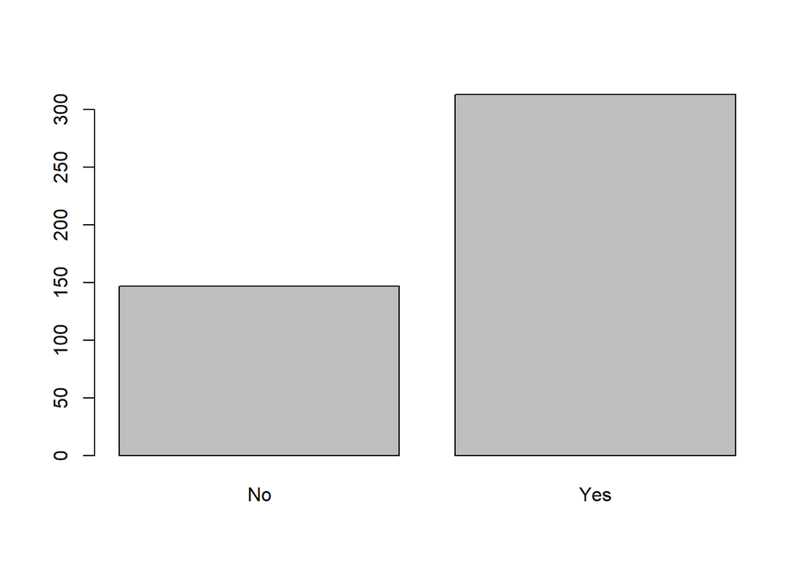

```r
barplot(table(good$Foreign_National))
```

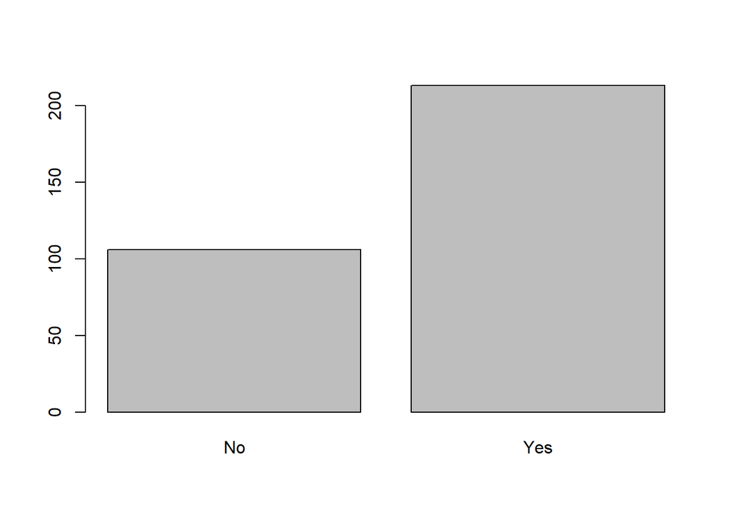

```r
barplot(table(bad$Foreign_National))
```

```r
table(good$Foreign_National) # mentioned alot of foreign nastionals however majority are good loas
```

```
##
##  No Yes
## 147 313
```

```r
table((bad$Foreign_National))# and bad and not froeign are pretty similar
```

```
##
##  No Yes
## 106 213
```

#### 2.2 Bivariate Data Analysis

From the univariate section a path of investigation was chosen to delve deeper into the variables Credit Standing, Credit History, Employment, Job Type, and Housing. The package ggplot2 was used to plot variables against each other for analysis. There are four main graphs of interest. Firstly, the relationship between Credit Standing and Employment was looked at.

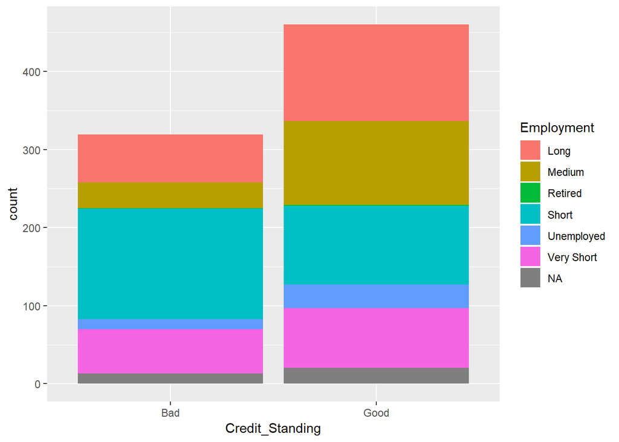

```r
ggplot(traindata, aes(x =Credit_Standing, fill = Employment)) +
  geom_bar() # good variable. shows to have more unemployed amd more nas in the good loan applicats which is against the norm
```

```r
# but alos has a good deal more people in long and medium employment
```

This plot again backs up our findings in the univariate section, that good loan applicants characteristically have long-medium termed employment therefore giving them sufficient income to keep up with loan repayments. Furthermore, these applicants also report having skilled and management level jobs indicating that they may report higher earning potential again reiterating that they will have sufficient income to pay off loans. However, the graph also shows more unskilled workers in the good category compared to the bad category, therefore in my opinion job type solely is not a sufficient parameter to deny loan applicants. it can certainly be used in conjunction with another variable for example Employment to use as a metric for defaulting.

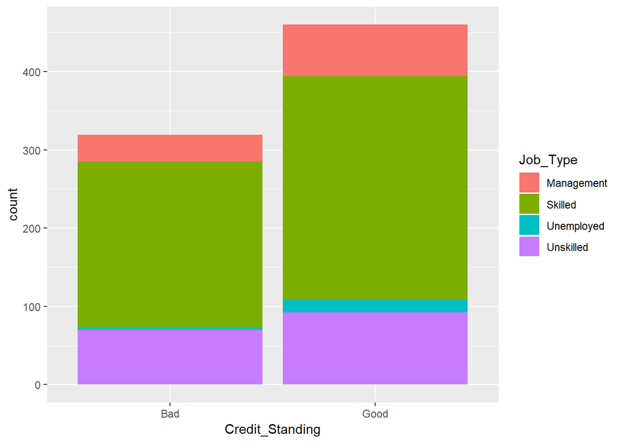

```r
ggplot(traindata, aes(x =Credit_Standing, fill = Job_Type)) +
  geom_bar()# as with emploment alot of skilled in both but more unskilled in good and more unemployed weird
```

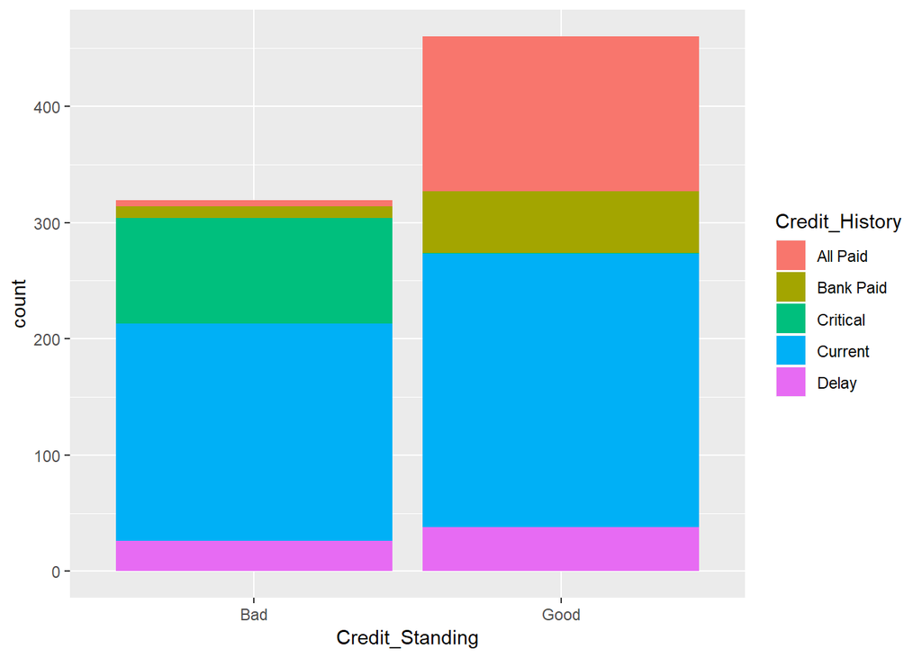

```r
ggplot(traindata, aes(x =Credit_Standing, fill = Credit_History)) +
  geom_bar()# fantastic all the critical applicats are termed bad loand very important variable indeciding credit worthiness so defo use
```

And lastly Housing was investigated as it is used in credit scoring as a type of collateral. It was observed again that good loan applicants tend to own properties when compared with the bad loan applicants.

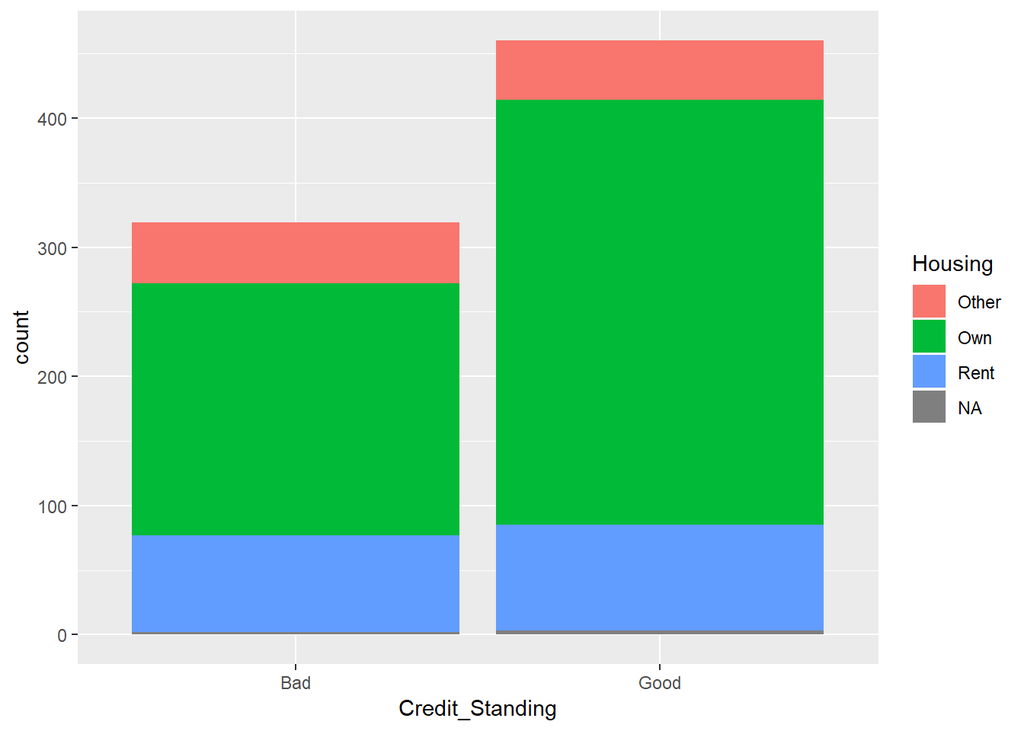

```r
ggplot(traindata, aes(x =Credit_Standing, fill = Housing)) +
  geom_bar() # most who are terned good have their own property good chpoice for picking it for credit scoring
```

#### 2.3 Multivariate Data Analysis

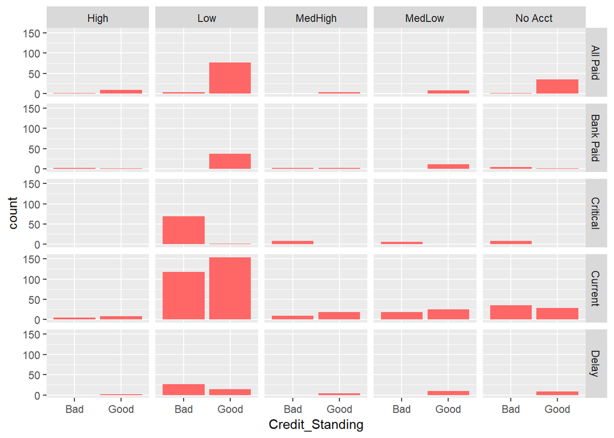

```r
tri <- ggplot(data = traindata, mapping = aes(x = Credit_Standing))+
  geom_bar(stat = "count",fill = "#FF6666", position = position_dodge())+ facet_grid(Credit_History~Savings_Acct)
tri
```

A trivariate analysis was carried out on Credit Standing, Credit History and Savings Account. The graph visualises what was being investigated on bad loan applicants. It clearly shows that bad loan applicants have a critical credit history and usually have a low balance. It also shows that many of the previous loan customers have current credit history with low savings account.

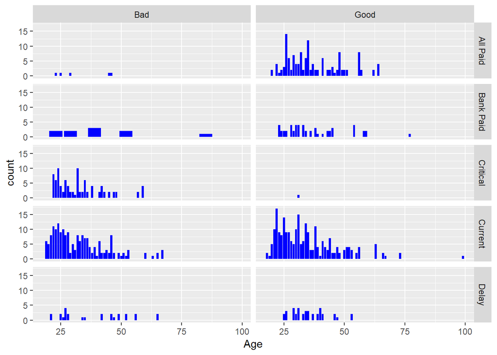

```r
triAge <-
  ggplot(data = traindata, mapping = aes(x = Age))+
  geom_bar(stat = "count",fill = "blue", position = position_dodge())+ facet_grid(Credit_History~Credit_Standing)
triAge
```

#### 2.4 Exploratory Data Analysis Conclusion

```r
table(traindata$Employment) # short term work is mode
```

```
##
##       Long     Medium    Retired      Short Unemployed Very Short
##        185        140          2        242         43        134
```

```r
traindata$Employment[is.na(traindata$Employment)] <- "Short" # fill in median for ramdon foresst
sum(is.na(traindata$Employment))
```

```
## [1] 0
```

```r
sum(is.na(traindata$Personal_Status))
```

```
## [1] 6
```

```r
table(traindata$Personal_Status) # single is meadia value ioccurs most often
```

```
##
## Divorced  Married   Single
##      273       70      430
```

```r
traindata$Personal_Status[is.na(traindata$Personal_Status)] <- "Single"
sum(is.na(traindata$Personal_Status))
```

```
## [1] 0
```

```r
sum(is.na(traindata$Housing))
```

```
## [1] 5
```

```r
table(traindata$Housing) # own is meadia value ioccurs most often
```

```
##
## Other   Own  Rent
##    93   524   157
```

```r
traindata$Housing[is.na(traindata$Housing)] <- "Own"

sum(is.na(traindata))
```

```
## [1] 0
```

```r
# all nas removed for random foresst fillend in with median or mode
```

## 3.0 ROC Curve

Historically the name “ROC” comes from communications theory and is an acronym for Receiver Operating Characteristics(1). The ROC curve shows two types of errors for all possible thresholds and is very popular as a performance graphic (5). The basis on the ROC curve as a performance metric is based on the fact that the area under an ROC curve gives the performance of a classifier summarised at all possible thresholds (5). An ideal ROC curve will hug the top left corner, so the larger area under the (ROC) curve the better the classifier (1).

```r
#![ROC][\Users\joyk9\Documents\Data_sc_Analytics\ROC.jpeg.jpg]
#[\Users\joyk9\Documents\Data_sc_Analytics\ROC.jpeg.jpg]: figures/ROC Curve.png
```

## 4.0 Decision Tree

As mentioned features were picked from the EDA and used to build a decision tree as well as using all variables in the dataset. Both decision trees were built and the model which included all the variables gave a slightly better result. So, this model will be used to go forward with the investigation. The main aim of this investigation is to determine a set of characteristics that define a bad loan applicant from a good loan applicant and therefore the target variable is Credit Standing. Considering our target variable and most other variables in the dataset are categorical it was concluded that the best decision tree to build would be a classification tree. The dataset was split into train and test data. It was decided for model accuracy to use a large training set, so the data was split 50:50(5). The package rpart and rpart.plot were used to create the classification tree, as they contain features for a visually appealing tree when compared to the basic tree package. The tree was built with the following code:

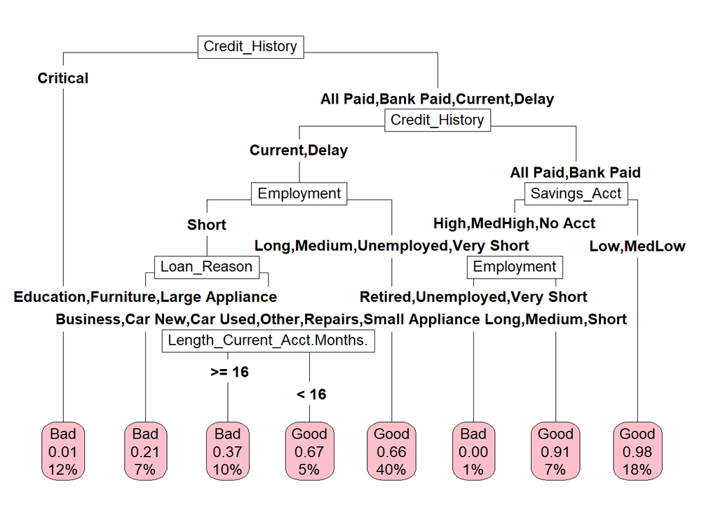

```r
# model building

Credit_Scoring=data.frame(traindata)

# Credit_standing is our target variable
Credit_Scoring.Model <- rpart(Credit_Standing~ Current_Acct+Credit_History+Loan_Reason+Savings_Acct+Employment+Personal_Status+Housing+
                            Job_Type+Foreign_National+Length_Current_Acct.Months.+Residence_Time.Years.+Age,
                              data=Credit_Scoring)

rpart.plot(Credit_Scoring.Model, type= 5, tweak =1.25, box.palette = "pink")
```

```r
summary(Credit_Scoring.Model) # lets summarise the model
```

```
## Call:
## rpart(formula = Credit_Standing ~ Current_Acct + Credit_History +
##     Loan_Reason + Savings_Acct + Employment + Personal_Status +
##     Housing + Job_Type + Foreign_National + Length_Current_Acct.Months. +
##     Residence_Time.Years. + Age, data = Credit_Scoring)
##   n= 779
##
##           CP nsplit rel error    xerror       xstd
## 1 0.28213166      0 1.0000000 1.0000000 0.04302440
## 2 0.06112853      1 0.7178683 0.7178683 0.03986022
## 3 0.02194357      3 0.5956113 0.5956113 0.03757293
## 4 0.01097179      5 0.5517241 0.5799373 0.03723228
## 5 0.01000000      7 0.5297806 0.5924765 0.03750572
##
## Variable importance
##              Credit_History                  Employment
##                          70                          18
## Length_Current_Acct.Months.                 Loan_Reason
##                           4                           4
##                Savings_Acct                         Age
##                           2                           1
##       Residence_Time.Years.                Current_Acct
##                           1                           1
##                    Job_Type
##                           1
##
## Node number 1: 779 observations,    complexity param=0.2821317
##   predicted class=Good  expected loss=0.4094994  P(node) =1
##     class counts:   319   460
##    probabilities: 0.409 0.591
##   left son=2 (92 obs) right son=3 (687 obs)
##   Primary splits:
##       Credit_History              splits as  RRLRR,    improve=70.097390, (0 missing)
##       Employment                  splits as  RRLLRL,   improve=19.667830, (0 missing)
##       Current_Acct                splits as  LLLR,     improve=13.062800, (0 missing)
##       Age                         < 28.5 to the left,  improve= 7.402696, (0 missing)
##       Length_Current_Acct.Months. < 8.5  to the right, improve= 6.057454, (0 missing)
##
## Node number 2: 92 observations
##   predicted class=Bad   expected loss=0.01086957  P(node) =0.1181001
```

[output cut: 117 more lines]

```
##
## Node number 29: 57 observations
##   predicted class=Good  expected loss=0.0877193  P(node) =0.07317073
##     class counts:     5    52
##    probabilities: 0.088 0.912
##
## Node number 50: 78 observations
##   predicted class=Bad   expected loss=0.3717949  P(node) =0.1001284
##     class counts:    49    29
##    probabilities: 0.628 0.372
##
## Node number 51: 42 observations
##   predicted class=Good  expected loss=0.3333333  P(node) =0.05391528
##     class counts:    14    28
##    probabilities: 0.333 0.667
```

```r
table(Credit_Scoring$Credit_Standing)/nrow(Credit_Scoring)
```

```
##
##       Bad      Good
## 0.4094994 0.5905006
```

```r
set.seed(161)# for reproducability
train=sample(1:nrow(Credit_Scoring), 390)
Credit_Scoring.test=Credit_Scoring[-train,]
high.test=Credit_Scoring$Credit_Standing[-train]
Credit_Scoring.Model=rpart(Credit_Standing~ Current_Acct+Credit_History+Loan_Reason+Savings_Acct+Employment+Personal_Status+Housing+
                            Job_Type+Foreign_National+Length_Current_Acct.Months.+Residence_Time.Years.+Age,
                          data=Credit_Scoring)

tree.pred=predict(Credit_Scoring.Model,Credit_Scoring.test,type="class") # predict
table(tree.pred, high.test)
```

```
##          high.test
## tree.pred Bad Good
##      Bad   97   22
##      Good  71  199
```

```r
(97+199)/389 #  0.7609
```

```
## [1] 0.7609254
```

## 5.0 Testing the Decision tree

Three different loan applicants were chosen at random from the Scoring data to test the decision trees accuracy. The applicants chosen were the following: 1. ID 783 2. ID 787 3. ID 791

Now letâs explain how the decision tree differentiates between bad and good loan applicants.

1. ID 783 The applicant ID 783 was taken and all their info. The root node of the decision tree asks, does this applicant have a Critical Credit History ? As we can see from their information they do not have a critical Credit history. So, we move right for no. Which leads us to the next node and the next question. Does this applicant have a Current/Delay Credit History? In this case our applicant does have a Current credit history and therefore the answer to the question is yes and so we move left down to the next node. This node asks does this applicant have Short employment? Our applicant has very short employment and so no they do not have short employment, so we move right for no down to the end of the tree and the applicant is labelled a good applicant for a loan.
2. ID 787 At the root node the question does this applicant have a critical credit history is asked and in this case the answer is no and so we move right down to the next node. This node asks the question is this loan applicant has a current/delay credit history and the answer is yes so, we move left down to the next node. This node asks the question is this applicant in short employment? Our applicant does not have short employment, so we move right for no. This applicant is labelled a good loan applicant.
3. ID 791 At the first node we are asked the question does this applicant have a critical credit history? And as can be seen from the scoring data our applicant does in fact have a critical credit history and so we move left for yes and they are straight away labelled a bad loan applicant. The Decision Tree algorithm was then used to check the above answers for these three potential loan applicants. The Scoring data containing these three applicants had to be input and their attributes changed to match the current dataset.

```r
Scoring_Data <- read.csv("Scoring Data.csv", sep = ",")
colnames(Scoring_Data) <- c('ID', 'Current_Acct', 'Credit_History','Loan_Reason', 'Savings_Acct', 'Employment', 'Personal_Status', 'Housing',
                            'Job_Type', 'Foreign_National', 'Length_Current_Acct.Months.', 'Residence_Time.Years.', 'Age')


Applicants <- subset(Scoring_Data[c(3,7,11),])



predict(Credit_Scoring.Model, Applicants, type = "class") # 3 applicants good or bad
```

```
##    3    7   11
## Good Good  Bad
## Levels: Bad Good
```

```r
predict(Credit_Scoring.Model, Applicants)
```

```
##          Bad       Good
## 3  0.3398058 0.66019417
## 7  0.3398058 0.66019417
## 11 0.9891304 0.01086957
```

The output is indeed the answers given above (ID 783 = Good, ID 787 = Good, & ID 791 = Bad). Therefore, it was proved that the model works for test data. However, the model is only 76% accurate and so more work will be carried out to try and increase the modelâs accuracy. As mentioned for a classification tree a confusion matrix is used to determine the accuracy of the model (i.e. The number of correct predictions made divided by the total number of predictions made).

## 6.0 Increasing Model Accuracy

There are three different ways to increase the accuracy of the model, ensemble technique, boosting or building a different model. Since the model is already at 76% accuracy it was decided that a new model would not need to be built and instead increasing the accuracy would try to be achieved through ensemble technique and boosting. The ensemble technique Random Forrest was chosen. Random Forrest is a type of supervised learning algorithm. Simply what Random Forrest does is builds multiple decision trees and merges them together to produce a more accurate and stable model(4). Random Forrest was carried out on our model and the best result generated was 73% accuracy.

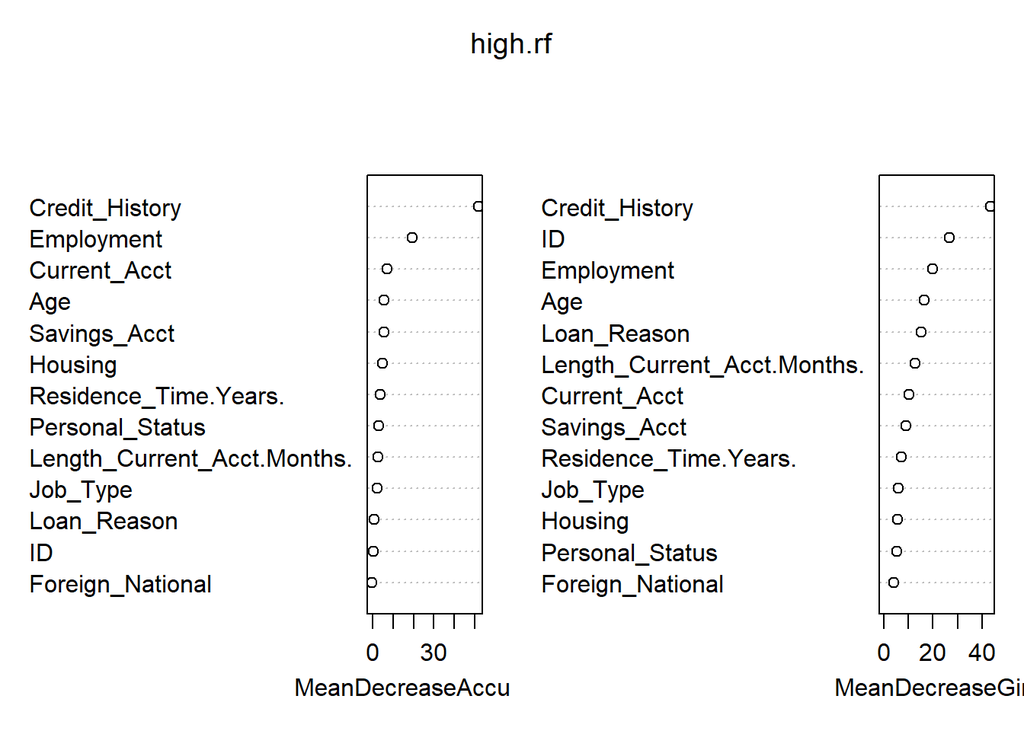

```r
set.seed(161)
high.rf <- randomForest(Credit_Standing~.,data = Credit_Scoring[train,], mtry=4, importance=TRUE, ntree=500)
varImpPlot(high.rf)
```

```r
rf.pred=predict(high.rf,Credit_Scoring.test,type="class")
table(rf.pred,high.test)
```

```
##        high.test
## rf.pred Bad Good
##    Bad   91   28
##    Good  77  193
```

```r
(94+191)/389
```

[output not shown]

```r
set.seed(161)
cred.adabag <- boosting(Credit_Standing~., data = Credit_Scoring[train,],v=10, boos = TRUE, mfinal=50,control=rpart.control(maxdepth=5))

yhat_cred_adabag=predict(cred.adabag,newdata=Credit_Scoring[-train,])
yhat_cred_adabag$confusion
```

```
##                Observed Class
## Predicted Class Bad Good
##            Bad   85   33
##            Good  83  188
```

```r
(102+178)/389
```

[output not shown]

However acuracy can be misleading in a model. It can instead predict the majority variables. therefore, it is in some cases better to select a model with lower accuracy because its predictive power is much greater(2).

## 7.0 Unbalanced Data

There are a number of ways to dealing with unbalanced data. These include resampling, getting more data or introducing more metrics to your model(2). Because we cannot resample or collect more data for this problem I am going to investigate two methods. One is to introduce an average cost per classification record and the other is to use metrics like cut off and costMatrix in random forest(2).  
In theory calculating an average cost per classification record and applying it to the confusion matrix would enable the algorithm to deal better with misclassification. In Random Forrest one could use a cut off point for misclassification or incorporate a costMatrix(3). This will increase a modelâs accuracy when it allows for metric to be involved after data analysis. On this occasion the code would not work for visual purposes therefore more research on how to incorporate these cost metrics into a model will have to be carried out.

## 8.0 Incorrect Data Entry

As mentioned earlier in the brief, upon exploring the data in the Exploratory Data Analysis section an inconsistence with data entry was observed in the Employment variable. A total of 33 missing values were recorded and it was observed that 31 of them were recorded consecutively between rows ID 89 to ID 120. It was also noted that Job Type was filled for all these applicants with missing employment records. This indicated that upon applying for the loan they did in fact provide information on their employability. This seems suspicious to have this many missing values in a row and therefore I would suggest it is down to incorrect data entry.

```r
grading <- subset(traindata[c(89:120),])
View(grading)
```

The code above generates the consecutive missing values in a data frame.

## 9.0 Conclusion

The best model generated was the first classification tree model. it has a 76% accuracy rate and strong predictive power. More work could be done on the model to improve its accuracy without hindering its predictive power. However, the model works and is simplistic therefore very easy to incorporate in a real time environment like Credit scoring. It will prove an effective asset in everyday credit scoring even if just used as a reference. The brief also demonstrates the power of machine learning algorithms and their potential application in the business world.

## References

1. A classic paper on using ROC curves, old, but still very relevant: Hanley, J. A. and B. J. McNeil (1982). âThe meaning and use of the area under a receiver operating characteristic (ROC) curve.â Radiology 143(1): 29-36.
2. Brownlee, J. (2018). Classification Accuracy is Not Enough: More Performance Measures You Can Use. [online] Machine Learning Mastery. Available at: https://machinelearningmastery.com/classification-accuracy-is-not-enough-more-performance-measures-you-can-use/ [Accessed 6 Dec. 2018].
3. Docs.oracle.com. (2018). Classification. [online] Available at: https://docs.oracle.com/cd/E11882_01/datamine.112/e16808/classify.htm#DMCON219 [Accessed 6 Dec. 2018].
4. Donges, N. (2018). The Random Forest Algorithm â Towards Data Science. [online] Towards Data Science. Available at: https://towardsdatascience.com/the-random-forest-algorithm-d457d499ffcd [Accessed 6 Dec. 2018].
5. Gareth James, Daniela Witten, Trevor Hastie, Robert Tibshirani. An Introduction to Statistical Learning : with Applications in R. New York :Springer, 2013. Print.
6. Rdocumentation.org. (2018). adabag-package function | R Documentation. [online] Available at: https://www.rdocumentation.org/packages/adabag/versions/4.2/topics/adabag-package [Accessed 6 Dec. 2018].